# Упражнение № 5

Александрова Александра

21 03 2021

## Вариант 2

1 Оценить стандартную ошибку модели для линейных регрессионных моделей из упражнения 4 (варианты ниже): а) со всеми объясняющими переменными; б) только с непрерывными объясняющими переменными:

- методом проверочной выборки с долей обучающей 50%;
- методом LOOCV;
- k-кратной кросс-валидацией с k=5 и k=10.

Выбрать лучшую модель по минимуму ошибки. Все ли методы кросс-валидации сходятся на одной и той же модели?

2 Оценить стандартные ошибки параметров лучшей модели регрессии методом бутстрепа. Вывести график остатков лучшей модели. Сравнить с оценками стандартных ошибок параметров по МНК.

## Описание переменных

Набор данных Boston содержит переменные:

*crim* - уровень преступности на душу населения в разбивке по городам;

*indus* - доля акров не розничного бизнеса на один город;

*tax* - полная стоимость имущества-ставка налога на имущество за $10 000;

*black* - 1000(Bk - 0.63)^2, где Bk-доля чернокожих по городам;

*chas* - Charles River (= 1, территория имеет водную границу; 0 территория не имеет водную границу);

Размерность обучающей выборки: n = 506 строк, p = 4 объясняющих переменных. Зависимая переменная – *crim*. Дискретная переменная - *chas*

### Метод перекрёстной проверки

Рассмотрим данные с характеристиками города Boston из пакета MASS. Скопируем таблицу во фрейм DF.boston для дальнейших манипуляций.

```r
my.seed <- 2

DF.boston <- subset(Boston, select = c(crim, tax, black, indus, chas))

#DF.boston <- Boston

head(DF.boston)
```

```
##      crim tax  black indus chas
## 1 0.00632 296 396.90  2.31    0
## 2 0.02731 242 396.90  7.07    0
## 3 0.02729 242 392.83  7.07    0
## 4 0.03237 222 394.63  2.18    0
## 5 0.06905 222 396.90  2.18    0
## 6 0.02985 222 394.12  2.18    0
```

```r
str(DF.boston)
```

```
## 'data.frame':    506 obs. of  5 variables:
##  $ crim : num  0.00632 0.02731 0.02729 0.03237 0.06905 ...
##  $ tax  : num  296 242 242 222 222 222 311 311 311 311 ...
##  $ black: num  397 397 393 395 397 ...
##  $ indus: num  2.31 7.07 7.07 2.18 2.18 2.18 7.87 7.87 7.87 7.87 ...
##  $ chas : int  0 0 0 0 0 0 0 0 0 0 ...
```

## Oписательные статистики по переменным

```r
summary(DF.boston)
```

```
##       crim               tax            black            indus
##  Min.   : 0.00632   Min.   :187.0   Min.   :  0.32   Min.   : 0.46
##  1st Qu.: 0.08205   1st Qu.:279.0   1st Qu.:375.38   1st Qu.: 5.19
##  Median : 0.25651   Median :330.0   Median :391.44   Median : 9.69
##  Mean   : 3.61352   Mean   :408.2   Mean   :356.67   Mean   :11.14
##  3rd Qu.: 3.67708   3rd Qu.:666.0   3rd Qu.:396.23   3rd Qu.:18.10
##  Max.   :88.97620   Max.   :711.0   Max.   :396.90   Max.   :27.74
##       chas
##  Min.   :0.00000
##  1st Qu.:0.00000
##  Median :0.00000
##  Mean   :0.06917
##  3rd Qu.:0.00000
##  Max.   :1.00000
```

```r
table(DF.boston$chas)
```

```
##
##   0   1
## 471  35
```

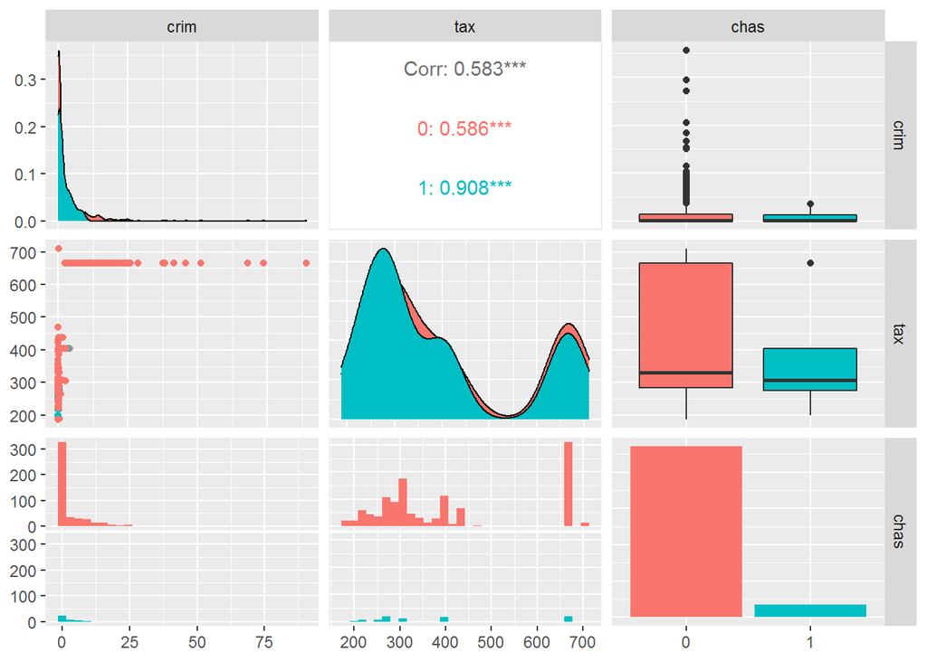

```r
# переводим дискретные количественные переменные в факторы
DF.boston$chas <- as.factor(DF.boston$chas)

# графики разброса, цвет -- количество цилиндров
ggpairs(DF.boston[, c(1, 2, 5)], ggplot2::aes(color = chas))
```

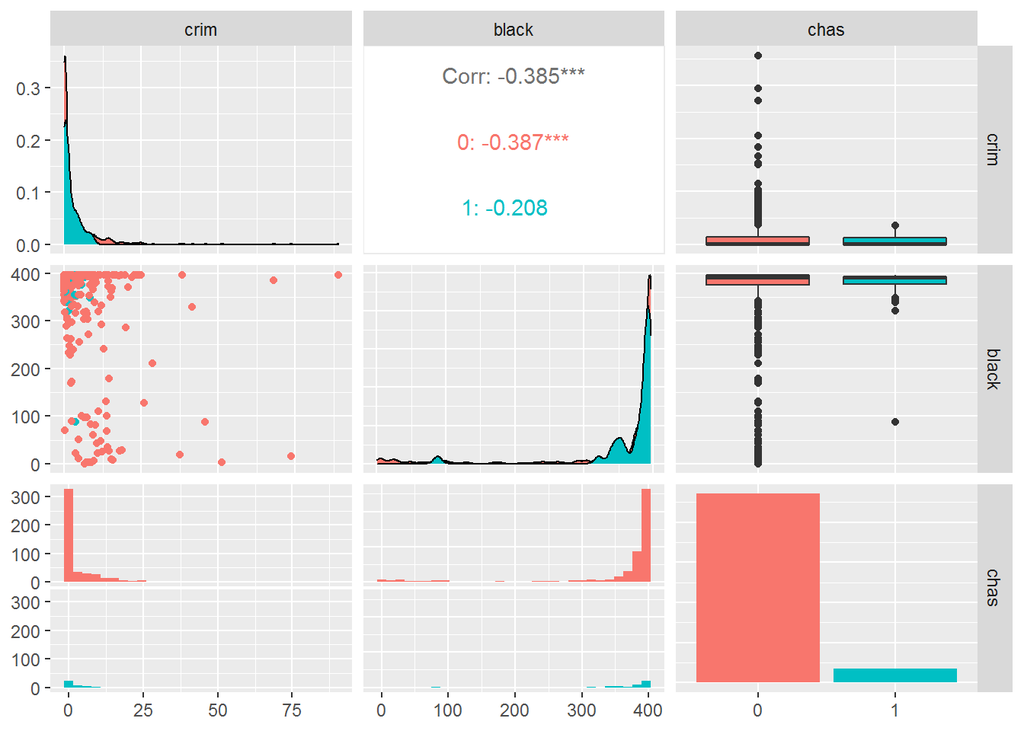

```r
ggpairs(DF.boston[, c(1, 3, 5)], ggplot2::aes(color = chas))
```

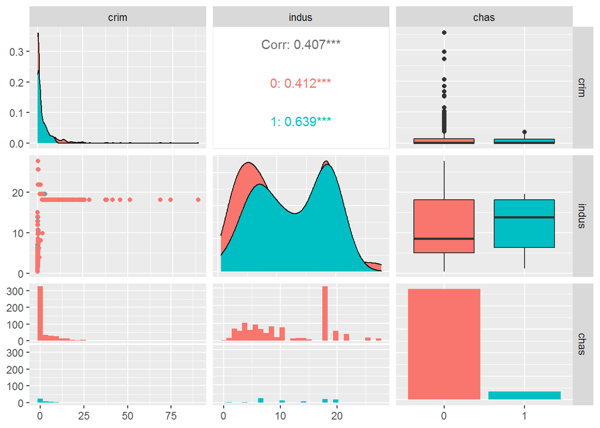

```r
ggpairs(DF.boston[, c(1, 4, 5)], ggplot2::aes(color = chas))
```

## Метод проверочной выборки

Он состоит в том, что мы отбираем одну тестовую выборку и будем считать на ней ошибку модели

[figure not shown]

```r
# общее число наблюдений
n <- nrow(DF.boston)

# доля обучающей выборки
train.percent <- 0.5

# выбрать наблюдения в обучающую выборку
set.seed(my.seed)
inTrain <- sample(1:n, n * train.percent)

# фактические значения Y на тестовой выборке
y.test.fact <- DF.boston$crim[-inTrain]

# рисуем разными цветами обучающую и тестовую
plot(DF.boston$tax [inTrain], DF.boston$crim[inTrain],
     xlab = 'tax ', ylab = 'crim', pch = 21,
     col = rgb(0, 0, 1, alpha = 0.4), bg = rgb(0, 0, 1, alpha = 0.4))
points(DF.boston$tax [-inTrain], DF.boston$crim[-inTrain],
       pch = 21, col = rgb(1, 0, 0, alpha = 0.4),
       bg = rgb(1, 0, 0, alpha = 0.4))
legend('topright',
       pch = c(16, 16), col = c('blue', 'red'), legend = c('test', 'train'))
```

[figure not shown]

```r
plot(DF.boston$indus[inTrain], DF.boston$crim[inTrain],
     xlab = 'indus', ylab = 'crim', pch = 21,
     col = rgb(0, 0, 1, alpha = 0.4), bg = rgb(0, 0, 1, alpha = 0.4))
points(DF.boston$indus[-inTrain], DF.boston$crim[-inTrain],
       pch = 21, col = rgb(1, 0, 0, alpha = 0.4),
       bg = rgb(1, 0, 0, alpha = 0.4))
legend('topright',
       pch = c(16, 16), col = c('blue', 'red'), legend = c('test', 'train'))
```

[figure not shown]

```r
plot(DF.boston$black[inTrain], DF.boston$crim[inTrain],
     xlab = 'black', ylab = 'crim', pch = 21,
     col = rgb(0, 0, 1, alpha = 0.4), bg = rgb(0, 0, 1, alpha = 0.4))
points(DF.boston$black[-inTrain], DF.boston$crim[-inTrain],
       pch = 21, col = rgb(1, 0, 0, alpha = 0.4),
       bg = rgb(1, 0, 0, alpha = 0.4))
legend('topright',
       pch = c(16, 16), col = c('blue', 'red'), legend = c('test', 'train'))
```

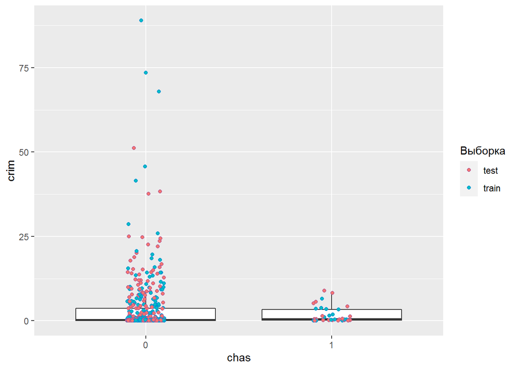

```r
DF.boston$Выборка <- 1
DF.boston$Выборка[inTrain] <- 2
DF.boston$Выборка <- as.factor(DF.boston$Выборка)
levels(DF.boston$Выборка) <- c('test','train')

ggplot(
  DF.boston, aes(x = chas, y = crim)) +
  geom_boxplot(outlier.shape = NA) +
  geom_jitter(aes(bg = Выборка),position = position_jitter(width = .1, height = 0),
  pch = 21, col = rgb(0, 0, 1, alpha = 0.4)
  )
```

Построим модели для проверки точности со всеми объясняющими переменными.

Вид моделей:

$$crim=f(tax + indus + black + chas)$$
Линейная модель:

```r
# присоединить таблицу с данными: названия стоблцов будут доступны напрямую
attach(DF.boston)

# подгонка модели на обучающей выборке
fit.lm.1_1 <- lm(crim ~ tax  + indus + black + chas, subset = inTrain)

# подгонка линейной модели на обучающей выборке
fit.lm.1_1 <- lm(crim ~ tax  + indus + black + chas,
               subset = inTrain)
# прогноз на тестовую
y.test.lm.1_1 <- predict(fit.lm.1_1, DF.boston[-inTrain, ])

# считаем MSE на тестовой выборке
MSE.lm.1_1 <- mean((y.test.fact - y.test.lm.1_1)^2)

# отсоединить таблицу с данными
detach(DF.boston)

# смотрим ошибку
MSE.lm.1_1
```

```
## [1] 23.10437
```

Строим квадратичную модель:

$$crim = β_0+β_1tax+β_2 indus + β_3 black + β_4chas + β_5 tax ^2 + β_6 indus^2 + β_7 black^2 + β_8 chas^2$$

```r
# присоединить таблицу с данными: названия стоблцов будут доступны напрямую
attach(DF.boston)

# подгонка модели на обучающей выборке
fit.lm.2_1 <- lm(crim ~ poly(tax , 2) + poly(indus, 2) + poly(black, 2) + chas, subset = inTrain)

# прогноз на тестовую
y.test.lm.2_1 <- predict(fit.lm.2_1, DF.boston[-inTrain, ])

# считаем MSE на тестовой выборке
MSE.lm.2_1 <- round(mean((y.test.fact - y.test.lm.2_1)^2), 2)

# отсоединить таблицу с данными

detach(DF.boston)

# смотрим ошибку
MSE.lm.2_1
```

```
## [1] 21.41
```

## Строим кубическую модель:

Присоединить таблицу с данными: названия стоблцов будут доступны напрямую

```r
attach(DF.boston)

# подгонка модели на обучающей выборке
fit.lm.3_1 <- lm(crim ~ poly(tax , 3)  + poly(indus, 3) + poly(black, 3) + chas,
               subset = inTrain)

# прогноз на тестовую
y.test.lm.3_1 <- predict(fit.lm.3_1, DF.boston[-inTrain, ])

# считаем MSE на тестовой выборке
MSE.lm.3_1 <- round(mean((y.test.fact - y.test.lm.3_1)^2), 2)

# отсоединить таблицу с данными
detach(DF.boston)

# смотрим ошибку
MSE.lm.3_1
```

```
## [1] 21.18
```

## Перекрёстная проверка по отдельным наблюдениям (LOOCV)

Это самый затратный в вычислительном плане метод, но и самый надёжный в плане оценки ошибки вне выборки. Попробуем применить его к линейной модели.

```r
# подгонка линейной модели на обучающей выборке
fit.glm_1 <- glm(crim ~ tax  + indus + black + chas, data = DF.boston)

# считаем LOOCV-ошибку
cv.err_1 <- cv.glm(DF.boston, fit.glm_1)

# результат: первое число -- по формуле LOOCV-ошибки,
#  второе -- с поправкой на смещение
cv.err_1$delta[1]
```

```
## [1] 48.668
```

Теперь оценим точность полиномиальных моделей, меняя степень, в которой стоит регрессор.

```r
# вектор с LOOCV-ошибками
cv.err.loocv_1 <- rep(0, 5)
# имена элементов вектора
names(cv.err.loocv_1) <- 1:5

# цикл по степеням полиномов
for (i in 1:5) {
  # оценка модели
  fit.glm_1 <- glm(crim ~ poly(tax , i)  + poly(indus, i) + poly(black, i) + chas, data = DF.boston)
  # расчёт ошибки
  cv.err.loocv_1[i] <- cv.glm(DF.boston, fit.glm_1)$delta[1]
}

# результат
cv.err.loocv_1
```

```
##        1        2        3        4        5
## 48.66800 46.32336 45.89720 45.76447 45.82784
```

Построим модели для проверки точности только c непрерывными переменными.

Вид моделей:

$$crim=f(tax + indus + black)$$

Линейная модель:

```r
# присоединить таблицу с данными: названия стоблцов будут доступны напрямую
attach(DF.boston)

# подгонка модели на обучающей выборке
fit.lm.1 <- lm(crim ~ tax  + indus + black, subset = inTrain)

# подгонка линейной модели на обучающей выборке
fit.lm.1 <- lm(crim ~ tax  + indus + black,
               subset = inTrain)
# прогноз на тестовую
y.test.lm.1 <- predict(fit.lm.1, DF.boston[-inTrain, ])

# считаем MSE на тестовой выборке
MSE.lm.1 <- mean((y.test.fact - y.test.lm.1)^2)

# отсоединить таблицу с данными
detach(DF.boston)

# смотрим ошибку
MSE.lm.1
```

```
## [1] 23.12708
```

Строим квадратичную модель:

$$crim = β_0 + β_1tax + β_2 indus + β_3 black + β_4tax ^2 + β_5 indus^2 + β_6 black^2$$

```r
# присоединить таблицу с данными: названия стоблцов будут доступны напрямую
attach(DF.boston)

# подгонка модели на обучающей выборке
fit.lm.2 <- lm(crim ~ poly(tax , 2) + poly(indus, 2) + poly(black, 2), subset = inTrain)

# прогноз на тестовую
y.test.lm.2 <- predict(fit.lm.2, DF.boston[-inTrain, ])

# считаем MSE на тестовой выборке
MSE.lm.2 <- round(mean((y.test.fact - y.test.lm.2)^2), 2)

# отсоединить таблицу с данными

detach(DF.boston)

# смотрим ошибку
MSE.lm.2
```

```
## [1] 21.6
```

## Строим кубическую модель:

Присоединить таблицу с данными: названия стоблцов будут доступны напрямую

```r
attach(DF.boston)

# подгонка модели на обучающей выборке
fit.lm.3 <- lm(crim ~ poly(tax , 3)  + poly(indus, 3) + poly(black, 3),
               subset = inTrain)

# прогноз на тестовую
y.test.lm.3 <- predict(fit.lm.3, DF.boston[-inTrain, ])

# считаем MSE на тестовой выборке
MSE.lm.3 <- round(mean((y.test.fact - y.test.lm.3)^2), 2)

# отсоединить таблицу с данными
detach(DF.boston)

# смотрим ошибку
MSE.lm.3
```

```
## [1] 21.37
```

## Перекрёстная проверка по отдельным наблюдениям (LOOCV)

Это самый затратный в вычислительном плане метод, но и самый надёжный в плане оценки ошибки вне выборки. Попробуем применить его к линейной модели.

```r
# подгонка линейной модели на обучающей выборке
fit.glm <- glm(crim ~ tax  + indus + black, data = DF.boston)

# считаем LOOCV-ошибку
cv.err <- cv.glm(DF.boston, fit.glm)

# результат: первое число -- по формуле LOOCV-ошибки,
#  второе -- с поправкой на смещение
cv.err$delta[1]
```

```
## [1] 48.68887
```

Теперь оценим точность полиномиальных моделей, меняя степень, в которой стоит регрессор.

```r
# вектор с LOOCV-ошибками
cv.err.loocv <- rep(0, 5)
# имена элементов вектора
names(cv.err.loocv) <- 1:5

# цикл по степеням полиномов
for (i in 1:5) {
  # оценка модели
  fit.glm <- glm(crim ~ poly(tax , i)  + poly(indus, i) + poly(black, i), data = DF.boston)
  # расчёт ошибки
  cv.err.loocv[i] <- cv.glm(DF.boston, fit.glm)$delta[1]
}

# результат
cv.err.loocv
```

```
##        1        2        3        4        5
## 48.68887 46.41380 46.05183 45.85982 45.88994
```

## k-кратная перекрёстная проверка

K-кратная кросс-валидация – компромисс между методом проверочной выборки и LOOCV. Оценка ошибки вне выборки ближе к правде, по сравнению с проверочной выборкой, а объём вычислений меньше, чем при LOOCV. Проведём 10-ти кратную и 5-ти кратную кросс-валидацию моделей разных степеней.

# 5-ти кратная

```r
# оценим точность полиномиальных моделей, меняя степень
# вектор с ошибками по 5-ти кратной кросс-валидации
cv.err.k.fold5 <- rep(0, 5)
# имена элементов вектора
names(cv.err.k.fold5) <- 1:5

# цикл по степеням полиномов
for (i in 1:5) {
  # оценка модели
  fit.glm <- glm(crim ~ poly(tax , i) + poly(indus, i) + poly(black, i), data = DF.boston)
  # расчёт ошибки
  cv.err.k.fold5[i] <- cv.glm(DF.boston, fit.glm, K = 5)$delta[1]
}

# результат
cv.err.k.fold5
```

```
##        1        2        3        4        5
## 48.56266 47.68198 46.28408 47.08396 45.63698
```

# 10-ти кратная

```r
# оценим точность полиномиальных моделей, меняя степень
# вектор с ошибками по 10-кратной кросс-валидации
cv.err.k.fold10 <- rep(0, 5)
# имена элементов вектора
names(cv.err.k.fold10) <- 1:5

# цикл по степеням полиномов
for (i in 1:5) {
  # оценка модели
  fit.glm <- glm(crim ~ poly(tax , i) + poly(indus, i) + poly(black, i), data = DF.boston)
  # расчёт ошибки
  cv.err.k.fold10[i] <- cv.glm(DF.boston, fit.glm, K = 10)$delta[1]
}

# результат
cv.err.k.fold10
```

```
##        1        2        3        4        5
## 49.25948 46.29511 47.22984 44.97552 44.42593
```

## для модели с фиктивной переменной

# 5-ти кратная

```r
# оценим точность полиномиальных моделей, меняя степень
# вектор с ошибками по 5-ти кратной кросс-валидации
cv.err.k.fold5_1 <- rep(0, 5)
# имена элементов вектора
names(cv.err.k.fold5_1) <- 1:5

# цикл по степеням полиномов
for (i in 1:5) {
  # оценка модели
  fit.glm_1 <- glm(crim ~ poly(tax , i) + poly(indus, i) + poly(black, i) + chas, data = DF.boston)
  # расчёт ошибки
  cv.err.k.fold5_1[i] <- cv.glm(DF.boston, fit.glm_1, K = 5)$delta[1]
}

# результат
cv.err.k.fold5_1
```

```
##        1        2        3        4        5
## 48.25834 46.70808 47.91991 45.15113 47.31615
```

# 10-ти кратная

```r
# оценим точность полиномиальных моделей, меняя степень
# вектор с ошибками по 10-кратной кросс-валидации
cv.err.k.fold10_1 <- rep(0, 5)
# имена элементов вектора
names(cv.err.k.fold10_1) <- 1:5

# цикл по степеням полиномов
for (i in 1:5) {
  # оценка модели
  fit.glm_1 <- glm(crim ~ poly(tax , i) + poly(indus, i) + poly(black, i) + chas, data = DF.boston)
  # расчёт ошибки
  cv.err.k.fold10_1[i] <- cv.glm(DF.boston, fit.glm_1, K = 10)$delta[1]
}

# результат
cv.err.k.fold10_1
```

```
##        1        2        3        4        5
## 48.90910 47.13990 45.12494 45.34171 46.49585
```

Объединим все ошибки в одну таблицу и отсортируем её по возрастанию MSE (с непрерывными) и MSE.1 (со всеми обяняющими переменными):

```r
# записываем все ошибки в таблицу
df.MSE <- data.frame(Модель = c('Линейная', 'Полином 2 степени',
                                'Полином 3 степени',
                                rep(paste('Полином', 1:5, 'степени'), 3)),
                     Проверка.точности = c(rep('Проверочная выборка 50%', 3),
                                           rep('LOOCV', 5),
                                           rep('Кросс-валидация, k = 5', 5),
                                           rep('Кросс-валидация, k = 10', 5)),
                     MSE = round(c(MSE.lm.1, MSE.lm.2, MSE.lm.3,
                                  cv.err.loocv, cv.err.k.fold10, cv.err.k.fold5), 2),
                     MSE = round(c(MSE.lm.1_1, MSE.lm.2_1, MSE.lm.3_1,
                                  cv.err.loocv_1, cv.err.k.fold10_1, cv.err.k.fold5_1), 2))

# все модели по возрастанию ошибки
df.MSE[order(df.MSE$MSE), ]
```

[output not shown]

Опираясь на результаты расчётов с кросс-валидацией, можно заключить, что на самом деле ошибка вне выборки у линейной модели выше, чем показывала MSE на тестовой выборке. В целом, ошибка методом проверочной выборки размером 50% от числа наблюдений занижает MSE и, следовательно, завышает точность моделей. Та же ситуация наблюдается и у моделей со всеми обяъсняющими переменными.

# Бутстреп

## Точность оценки параметра регрессии

При построении модели регрессии проблемы в остатках приводят к неверной оценке ошибок параметров. Обойти эту проблему можно, применив для расчёта этих ошибок бутстреп.

```r
# Оценивание точности линейной регрессионной модели ----------------------------

# оценить стандартные ошибки параметров модели
#  crim = beta_0 + beta_1 * horsepower с помощью бутстрепа,
#  сравнить с оценками ошибок по МНК

# функция для расчёта коэффициентов ПЛР по выборке из данных
boot.fn <- function(data, index){
  coef(lm(crim ~ tax  + indus + black, data = data, subset = index))
}
boot.fn(DF.boston, 1:n)
```

```
## (Intercept)         tax       indus       black
## -1.70057010  0.02762649 -0.05123531 -0.01512157
```

# применениe функции к бутстреп-выборке

```r
set.seed(my.seed)
boot.fn(DF.boston, sample(n, n, replace = T))
```

```
## (Intercept)         tax       indus       black
## -1.48878257  0.03092901 -0.05381778 -0.01805044
```

применяем функцию boot для вычисления стандартных ошибок параметров

```r
#  (1000 выборок с повторами)
boot(DF.boston, boot.fn, 1000)
```

```
##
## ORDINARY NONPARAMETRIC BOOTSTRAP
##
##
## Call:
## boot(data = DF.boston, statistic = boot.fn, R = 1000)
##
##
## Bootstrap Statistics :
##        original        bias    std. error
## t1* -1.70057010 -6.032797e-03 3.487620526
## t2*  0.02762649 -6.593843e-05 0.003085481
## t3* -0.05123531  4.400368e-04 0.033203070
## t4* -0.01512157  5.068345e-05 0.007676693
```

сравним с ошибками параметров по МНК

```r
# К
summary(fit.lm.1)$coef
```

```
##                Estimate  Std. Error    t value     Pr(>|t|)
## (Intercept) -2.25610827 3.290769585 -0.6855868 4.936115e-01
## tax          0.03022018 0.004979840  6.0685045 4.779485e-09
## indus       -0.08491892 0.115073142 -0.7379561 4.612360e-01
## black       -0.01509216 0.006607279 -2.2841712 2.320374e-02
```

```r
summary(fit.lm.1_1)$coef
```

```
##                Estimate  Std. Error    t value     Pr(>|t|)
## (Intercept) -2.17216358 3.299374124 -0.6583563 5.109199e-01
## tax          0.02985712 0.005034210  5.9308460 1.006719e-08
## indus       -0.07421223 0.117009222 -0.6342425 5.265071e-01
## black       -0.01504078 0.006617581 -2.2728511 2.389131e-02
## chas1       -1.21932093 2.308435828 -0.5282022 5.978313e-01
```

график остатков модели

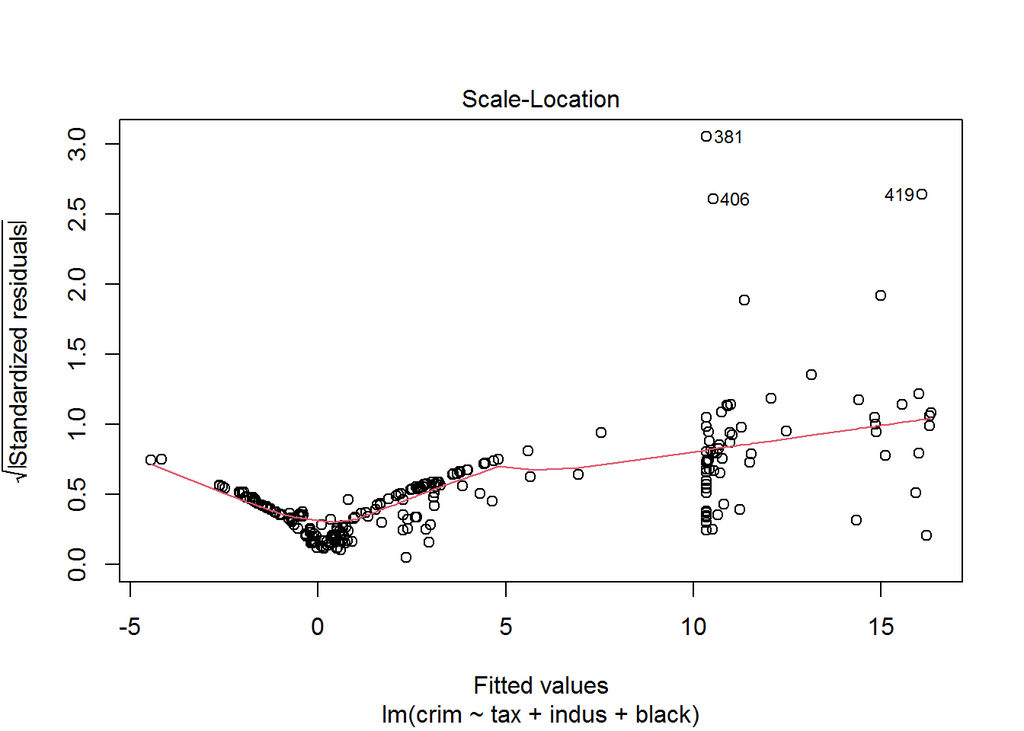

```r
plot(fit.lm.1, 3)
```

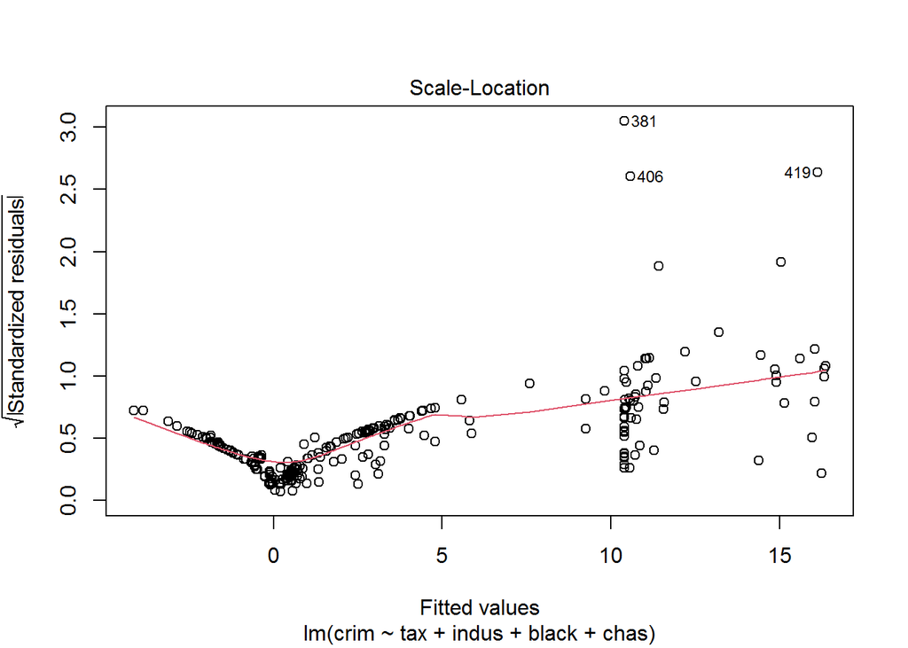

```r
plot(fit.lm.1_1, 3)
```

```r
# вычислим оценки параметров квадратичной модели регрессии
boot.fn.2 <- function(data, index){
  coef(lm(crim ~ poly(tax , 2) + poly(indus, 2) +  poly(black, 2), data = data, subset = index))
}
# применим функцию к 1000 бутсреп-выборкам
set.seed(my.seed)
boot(DF.boston, boot.fn.2, 1000)
```

```
##
## ORDINARY NONPARAMETRIC BOOTSTRAP
##
##
## Call:
## boot(data = DF.boston, statistic = boot.fn.2, R = 1000)
##
##
## Bootstrap Statistics :
##       original       bias    std. error
## t1*   3.613524 -0.007095499   0.2905006
## t2* 101.415949  0.108520780  11.3857483
## t3*  33.755663 -0.071387756   3.9711613
## t4*  -1.980236  0.038950243   3.5979658
## t5* -19.448327  0.673470387   5.2311496
## t6* -27.013487  0.187439079  15.4245880
## t7*  11.442946  0.106236316  10.5094656
```

сравним с ошибками параметров по МНК

```r
summary(fit.lm.2)$coef
```

```
##                   Estimate Std. Error     t value     Pr(>|t|)
## (Intercept)       3.839987  0.5282099  7.26981209 4.771654e-12
## poly(tax, 2)1   111.934896 18.5552941  6.03250453 5.890787e-09
## poly(tax, 2)2    35.190147 12.1593419  2.89408318 4.144010e-03
## poly(indus, 2)1  -8.851676 17.6712306 -0.50090885 6.168832e-01
## poly(indus, 2)2 -28.003588 11.6690495 -2.39981741 1.714756e-02
## poly(black, 2)1 -26.162297 13.3969074 -1.95286094 5.197005e-02
## poly(black, 2)2   1.258063 12.8189622  0.09814075 9.219005e-01
```

```r
summary(fit.lm.2_1)$coef
```

```
##                   Estimate Std. Error    t value     Pr(>|t|)
## (Intercept)       3.926548   0.546533  7.1844658 8.082527e-12
## poly(tax, 2)1   110.316715  18.756069  5.8816545 1.325005e-08
## poly(tax, 2)2    35.055314  12.176233  2.8789950 4.342083e-03
## poly(indus, 2)1  -6.885188  17.968062 -0.3831903 7.019109e-01
## poly(indus, 2)2 -28.498981  11.710050 -2.4337198 1.566029e-02
## poly(black, 2)1 -25.991295  13.416196 -1.9373073 5.385724e-02
## poly(black, 2)2   1.320500  12.835159  0.1028815 9.181412e-01
## chas1            -1.427246   2.272997 -0.6279135 5.306455e-01
```

график остатков модели

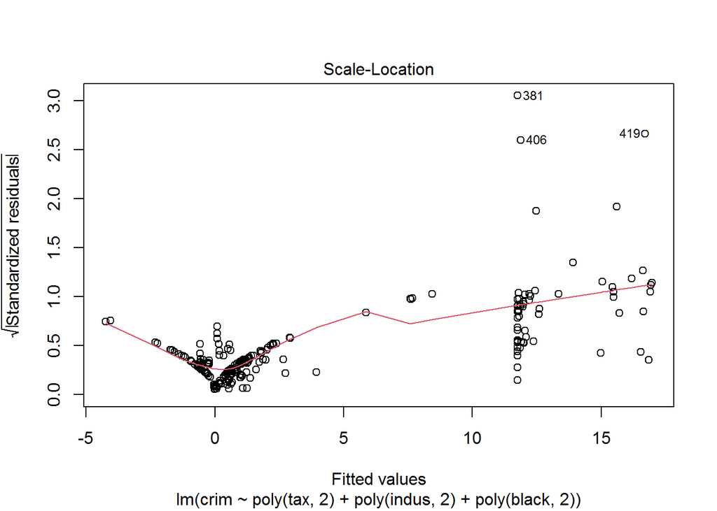

```r
plot(fit.lm.2, 3)
```

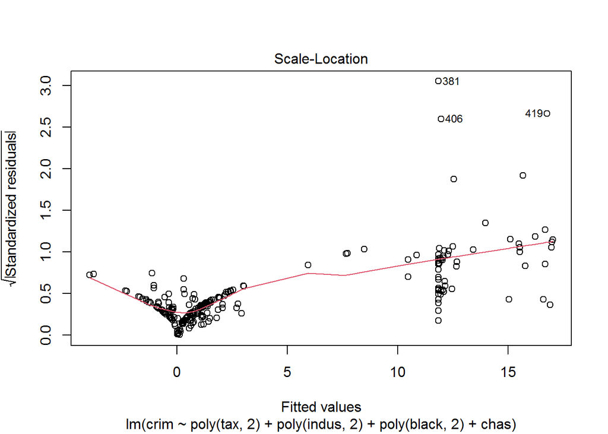

```r
plot(fit.lm.2_1, 3)
```